# Indel Signature InsDel_K

# InsDel_K

(corresponds to 83-type signature ID_K)

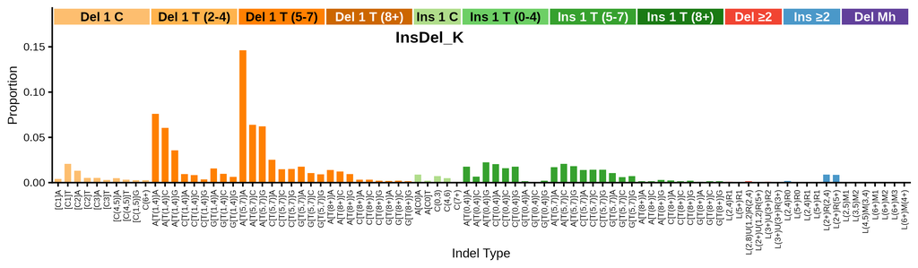

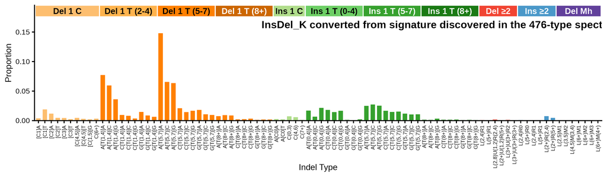

89-type spectrum of the linking tumor SP17905 | cosine similarity to InsDel_K: 0.8572

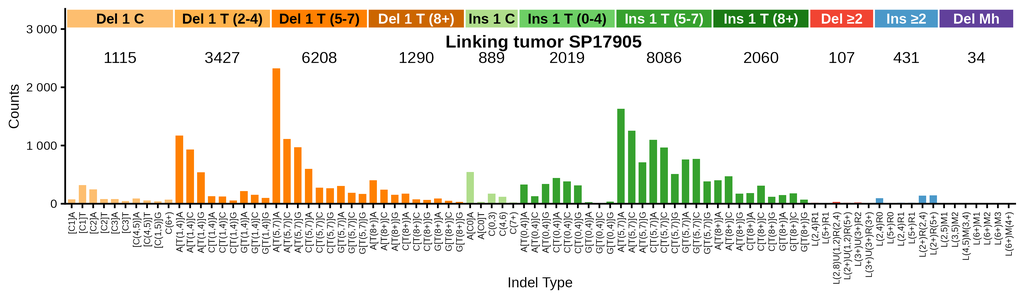

**Click to view decomposition of the linking tumor spectrum**

Partial mutation signature of SP17905 due to InsDel_K

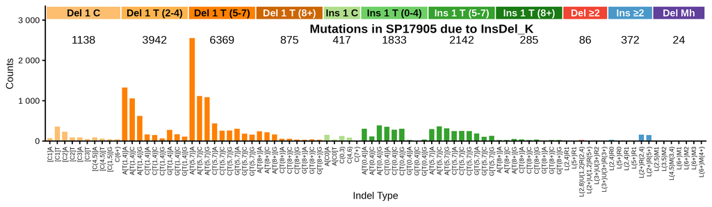

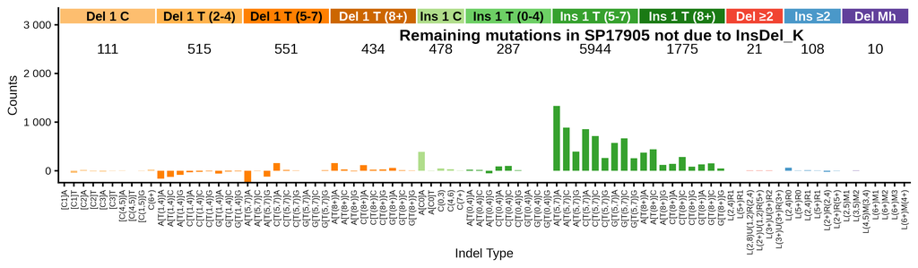

Max neg fraction (maximum allowed negative residual count as fraction of total): 0.04  
N subtract (mutation count assigned to signature): 17484.4  
N residual (mutation count in residual “partial spectrum”): 8181.6  
Total negative (sum of negative residual mutation counts): 1026.4  
N negative channels (number of channels with negative residual): 26  
P(≥ total negative) (Monte Carlo estimated probability that negative-binomial-sampled spectra from the signature contributing N subtract mutations would produce a total negative count >= the observed Total negative; higher number means not surprising): 0.853

**Per-channel residual breakdown**

| Channel | Spectrum | Sig_Count | Residual | Sig_Prop |
| --- | --- | --- | --- | --- |
| [Del(C):R1]A | 74 | 72.6 | 1.4 | 0.00415 |
| [Del(C):R1]T | 321 | 360.2 | -39.2 | 0.02060 |
| [Del(C):R2]A | 247 | 230.2 | 16.8 | 0.01316 |
| [Del(C):R2]T | 82 | 90.2 | -8.2 | 0.00516 |
| [Del(C):R3]A | 79 | 92.6 | -13.6 | 0.00529 |
| [Del(C):R3]T | 48 | 50.5 | -2.5 | 0.00289 |
| [Del(C):R(4,5)]A | 92 | 88.6 | 3.4 | 0.00507 |
| [Del(C):R(4,5)]T | 58 | 58.9 | -0.9 | 0.00337 |
| [Del(C):R(1,5)]G | 43 | 45.8 | -2.8 | 0.00262 |
| Del(C):R(6,9) | 71 | 48.4 | 22.6 | 0.00277 |
| A[Del(T):R(1,4)]A | 1170 | 1329.5 | -159.5 | 0.07604 |
| A[Del(T):R(1,4)]C | 934 | 1058.1 | -124.1 | 0.06052 |
| A[Del(T):R(1,4)]G | 540 | 623.6 | -83.6 | 0.03567 |
| C[Del(T):R(1,4)]A | 132 | 164.6 | -32.6 | 0.00941 |
| C[Del(T):R(1,4)]C | 126 | 146.9 | -20.9 | 0.00840 |
| C[Del(T):R(1,4)]G | 56 | 63.8 | -7.8 | 0.00365 |
| G[Del(T):R(1,4)]A | 218 | 275.1 | -57.1 | 0.01574 |
| G[Del(T):R(1,4)]C | 153 | 170.0 | -17 | 0.00972 |
| G[Del(T):R(1,4)]G | 98 | 110.5 | -12.5 | 0.00632 |
| A[Del(T):R(5,7)]A | 2324 | 2555.8 | -231.8 | 0.14618 |
| A[Del(T):R(5,7)]C | 1112 | 1117.2 | -5.2 | 0.06389 |
| A[Del(T):R(5,7)]G | 969 | 1088.0 | -119 | 0.06223 |
| C[Del(T):R(5,7)]A | 598 | 438.8 | 159.2 | 0.02510 |
| C[Del(T):R(5,7)]C | 277 | 258.5 | 18.5 | 0.01479 |
| C[Del(T):R(5,7)]G | 267 | 261.7 | 5.3 | 0.01497 |
| G[Del(T):R(5,7)]A | 306 | 306.0 | 0 | 0.01750 |
| G[Del(T):R(5,7)]C | 187 | 184.9 | 2.1 | 0.01058 |
| G[Del(T):R(5,7)]G | 168 | 158.3 | 9.7 | 0.00905 |
| A[Del(T):R(8,)]A | 402 | 243.6 | 158.4 | 0.01393 |
| A[Del(T):R(8,)]C | 243 | 216.4 | 26.6 | 0.01238 |

[output cut: 59 more lines]

**Click to view similar signatures from Koh et al.**

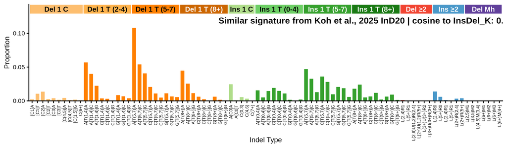

## 476-type representations corresponding to InsDel_K

Extracted 476-type signature corresponding to InsDel_K

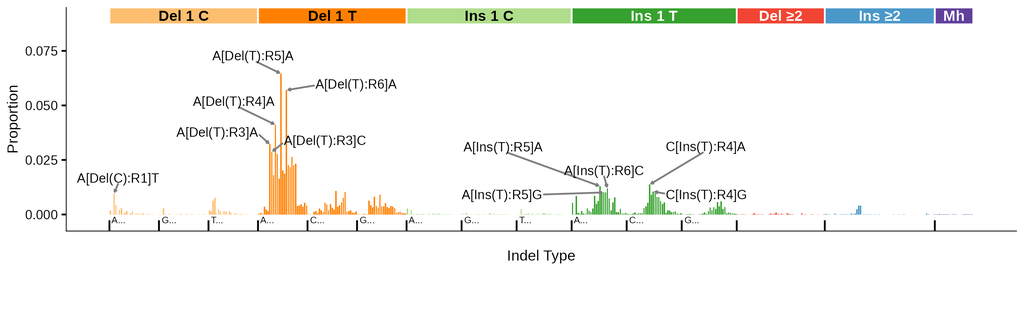

476-type spectrum of the linking tumor SP17905; cosine similarity to the extracted 476-type signature is 0.8578

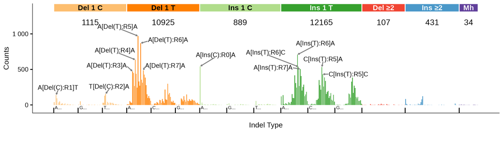

## 83-type signature corresponding to InsDel_K (ID_K)

**Note**

WARNING: The 83-type ID_K extraction excluded of T insertions in long poly-T contexts that were detected in extractions in the 89-type and 476-type classifications.

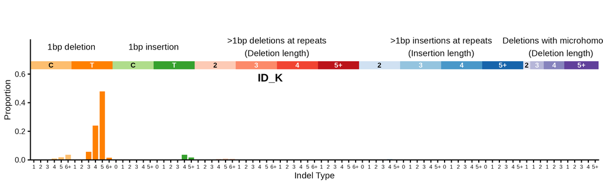

83-type signature converted from signature discovered in the 476-type spectra (using bipartite matching optimization) | cosine similarity to ID_K: 0.499

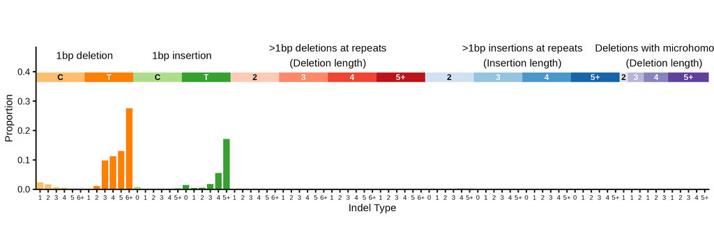

**Click here to see with insertions and deletions of T in long poly-T suppressed**

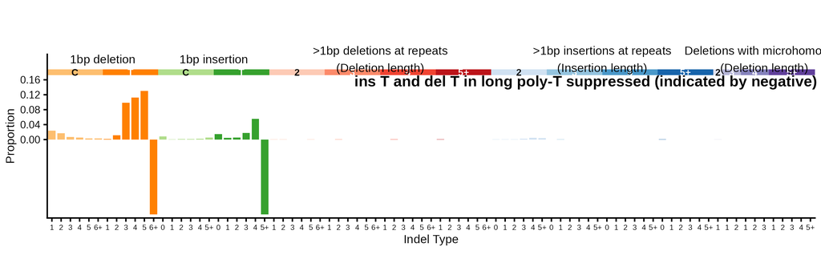

**Click to see flow diagrams: 476-type to 83-type collapse**

These Sankey diagrams show how the 476-type mutation categories are redistributed to 83-type categories using bipartite matching. We only show the diagrams for insertions or deletions of > 1 base because it is for these indels that 476-type categories map to > 1 83-type category.

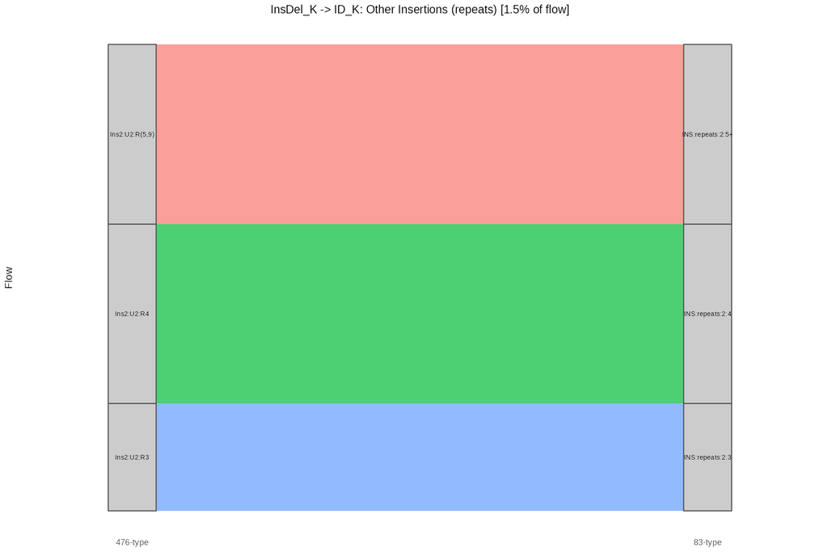

83-type spectrum of the linking tumor SP17905 | cosine similarity to ID_K: 0.2703

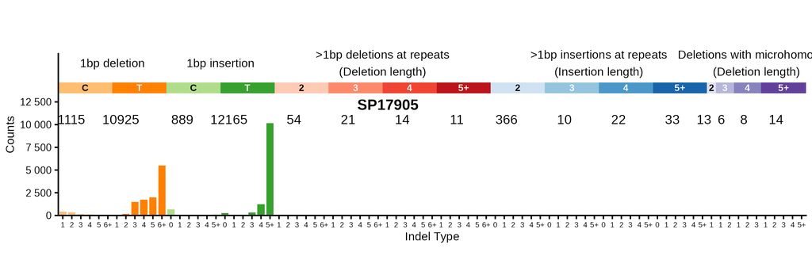

**Click here to see with insertions and deletions of T in long poly-T suppressed**

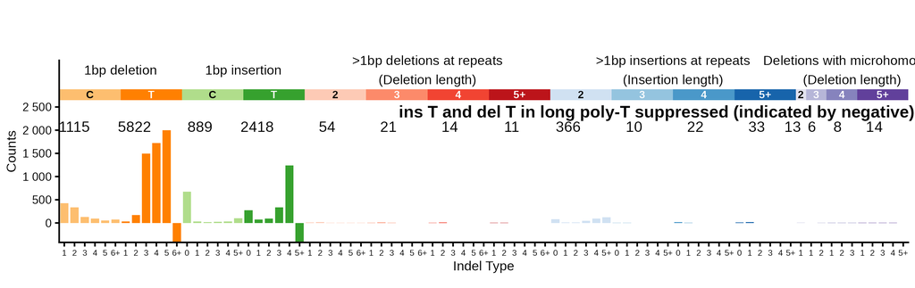

83-type spectrum of best 83-type matching tumor SP112257 | cosine similarity to ID_K: 0.5672

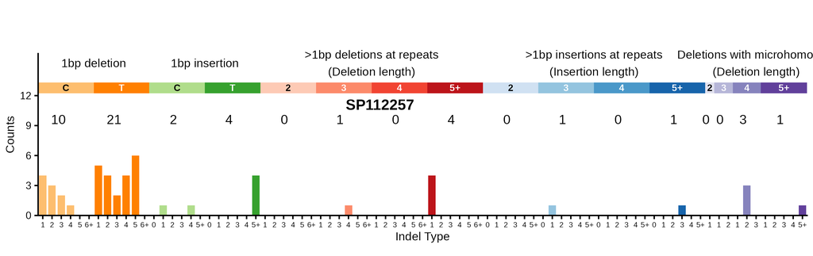

### Similar signatures from Jin et al. 2024

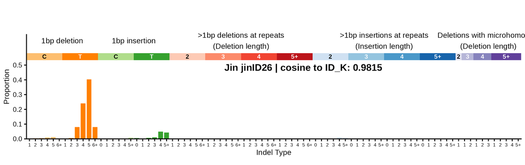